# Awards

Roman Rivera

1/21/2018

# Awards

INTRO/EXPLANATION

Our records indicate that about 699,912 awards were requested between 2005-03-10 and 2017-08-27. After an award is requested, it may be finalized (77.9%), deleted (19.79%), or denied (2.31%). While there are 45 unique award types, the distribution is highly skewed. The 4 most common award types comprise 82.6% of all award requests. While most (94%) of these awards went to identifiable CPD officers, 6% will be discarded as they went to other employees, such as Crossing Guards and Detention Aides. The 496,641 observations of officers with known information (21,409 unique officers), finalized award status, and between 2006 and 2016 (full years of information) will be kept for the remainder of this analysis.

# Award Types

The distribution of award types is highly skewed, with “Honorable Mention” awards comprising 60.23% of the finalized awards to known officers. The top 4 most common awards are Honorable Mention (60.23%), Complimentary Letter (12.41%), Department Commendation (5.07%), and Emblem Of Recognition - Physical Fitness (4.91%). With a total of 299,131 Honorable Mention awards being requested in this data, the average officer in this data has 14 HONORABLE MENTION awards. As displayed by the plots below display, there is a great deal of variation in the number of awards requested each year.

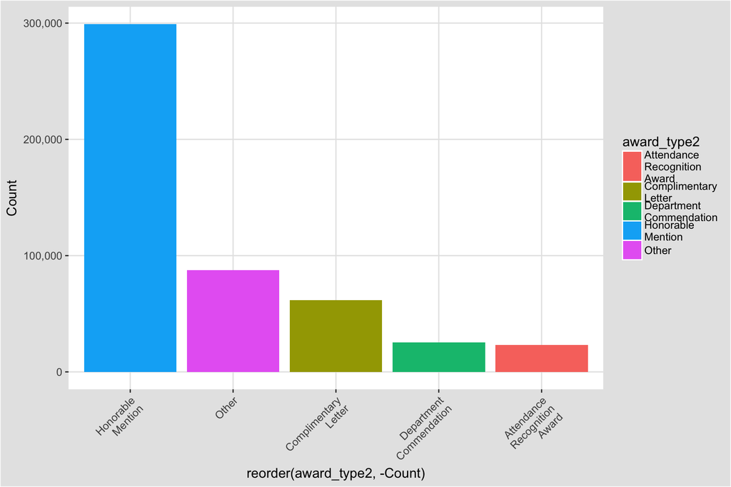

[interactive chart not shown]

While the variation on ‘Other’ awards can be largley attributed to the event-specific awards which make up 7.67% of the data and are all assigned at the same time to (almost) all officers– such as the 2009 Crime Reduction Award and the Presidential Election Deployment Award 2008, both awarded in 2011, and the Nato Summit Service Award awarded in 2013. However, Complimentary Letter awards, are incredibly inconsistent. While only 15 were requested in 2010, 16,552 were requested in 2011. On the other end, some awards are incredibly rare and prestigious, such as the Lambert Tree Award which is given to one member of the Chicago Police and Fire Department each year for outstanding bravery. Our data only contains 6 of these awards.

All Awards

|  | N | Percent |
| --- | --- | --- |
| Honorable Mention | 299131 | 60.23 |
| Complimentary Letter | 61649 | 12.41 |
| Department Commendation | 25178 | 5.07 |
| Emblem Of Recognition - Physical Fitness | 24369 | 4.91 |
| Attendance Recognition Award | 23122 | 4.66 |
| 2009 Crime Reduction Award | 13375 | 2.69 |
| Presidential Election Deployment Award 2008 | 12744 | 2.57 |
| Nato Summit Service Award | 11954 | 2.41 |
| Unit Meritorious Performance Award | 3863 | 0.78 |
| Special Commendation | 3055 | 0.62 |
| Deployment Operations Center Award | 2777 | 0.56 |
| Joint Operations Award | 2710 | 0.55 |
| Problem Solving Award | 2507 | 0.50 |
| Life Saving Award | 2255 | 0.45 |
| Honorable Mention Ribbon Award | 1408 | 0.28 |
| Police Officer Of The Month Award | 1288 | 0.26 |
| Recognition / Outside Governmental Agency Award | 852 | 0.17 |
| Superintendents Award Of Valor | 736 | 0.15 |
| Traffic Stop Of The Month Award | 680 | 0.14 |
| Arnold Mireles Special Partner | 532 | 0.11 |
| Superintendent’s Honorable Mention | 495 | 0.10 |
| Military Service Award | 458 | 0.09 |
| Superintendents Award Of Merit | 456 | 0.09 |
| Top Gun Arrest Award | 166 | 0.03 |
| Outside Governmental Agency Award | 150 | 0.03 |
| Emblem Of Recognition - Appearance | 141 | 0.03 |
| Annual Bureau Award Of Recognition | 137 | 0.03 |
| Military Deployment Award | 108 | 0.02 |
| Police Blue Star Award | 84 | 0.02 |
| Special Service Award | 70 | 0.01 |
| Pipe Band Award | 40 | 0.01 |
| Police Blue Shield Award | 32 | 0.01 |
| Chicago Police Leadership Award | 30 | 0.01 |
| Award Of Appreciation | 24 | 0.00 |
| Special Honorable Mention | 13 | 0.00 |
| William Powers Leadership Award | 9 | 0.00 |
| Thomas Wortham Iv Military And Community Service Award | 8 | 0.00 |
| Police Medal | 7 | 0.00 |
| Superintendent’s Award Of Tactical Excellence | 7 | 0.00 |
| Hundred Club Of Cook County Medal Of Valor | 6 | 0.00 |
| Lambert Tree | 6 | 0.00 |
| Other Awards | 6 | 0.00 |
| Carter Harrison | 3 | 0.00 |
| Total | 496641 | 100.00 |

# Award Recipients

As previously noted, the award recipients who could not be positively identified as known CPD officers were not included in this summary. There are 21,409 remaining CPD officers 99.99% of which have non-missing race information, which will be kept for this section.

|  | Black Female | Black Male | Hispanic Female | Hispanic Male | Other Female | Other Male | White Female | White Male |
| --- | --- | --- | --- | --- | --- | --- | --- | --- |
| **Average Awards** |  |  |  |  |  |  |  |  |
| Honorable Mention | 5.11 | 9.82 | 11.19 | 23.23 | 11.23 | 22.47 | 9.53 | 14.79 |
| Complimentary Letter | 2.41 | 2.60 | 2.56 | 3.00 | 2.66 | 3.25 | 2.82 | 3.02 |
| Departmet Commedation | 0.44 | 0.84 | 0.86 | 1.88 | 0.69 | 1.58 | 0.78 | 1.28 |
| Other | 0 | 0 | 0 | 0 | 0 | 0 | 0 | 0 |
| **Total Awards** |  |  |  |  |  |  |  |  |
| N (awards) | 17939 | 60759 | 13932 | 96035 | 1208 | 14652 | 35751 | 256351 |
| % (awards) | 3.61 | 12.23 | 2.81 | 19.34 | 0.24 | 2.95 | 7.2 | 51.62 |
| **Unique Officers** |  |  |  |  |  |  |  |  |
| N (officers) | 1435 | 3365 | 693 | 2727 | 61 | 425 | 1985 | 10716 |
| % (officers) | 6.7 | 15.72 | 3.24 | 12.74 | 0.28 | 1.99 | 9.27 | 50.06 |